# HDS 7. Statistical inference for penalized regression

Matti Pirinen, University of Helsinki

26.11.2019

### From prediction to inference

During the last two weeks, we have been using the predictive ability as the criterion to choose between the regression models. In practice, we have done this via cross-validation that puts the models in an empirical test against data that has not been included in the training data set. This sounds a very reasonable approach to choose models when the goal is to predict well future outcomes.

More broadly, we also intuitively expect that models that are able to best predict the outcome value from the input predictors, are also best in “capturing” the phenomenon we want to study. Therefore, we would also like to extract more information about the phenomenon from those best models than what the point estimates of the coefficients alone give us. A single set of point estimates does not, for example, answer questions such as

- What is our level of confidence that this particular coefficient $\beta_j$ is non-zero (probability of being important), or that its value is within a particular interval $[a,b]$?
- Are there dependencies between multiple predictors so that they seem to be all needed together for the model to work well? And what are such dependencies in numerical terms?
- Could predictor $j$ in the chosen model be equally well replaced by another predictor $k$, or some combination of several other predictors?

Answers to such questions require that we quantify our certainty/uncertainty about the chosen model and about the values of the coefficients within the chosen model. In other words, we want to do statistical inference in addition to doing predictions. While there are standard approaches to inference in any one (unpenalized) regression model, such as using the variance-covariance matrix of the ML-estimator to derive confidence intervals/regions, no equally general approach is (yet) available for the penalized models. Here we will approach the problem from two angles:

1. Empirical quantification of variability of our estimation method by using data resampling also known as the **bootstrap**.
2. Estimating the posterior distribution for the model and its parameters.

The first one, the bootstrap, is a very generally applicable idea of using the observed data set to generate additional possible data sets and quantifying how much variation there is in the parameter estimates of the method when applied across the generated data sets. The flavor of bootstrapping is very practical and it can be interpreted both as an approximate method to estimate the sampling distribution of the parameters of interest and as a Bayesian method to estimate the posterior distribution under certain naive prior distribution about the observed data.

The second approach, the full posterior distribution of all the unknown quantities, is a theoretically sound way to quantify uncertainty, but it is often technically complicated and hence available in special cases rather than in general. A current work on probabilistic programming (e.g. [Stan](https://mc-stan.org/)) is aiming to bridge this gap and make the posterior inference more easily available for wider audience.

## Bootstrap

Let’s consider the problem of estimating the correlation coefficient $r$ between variables $x$ and $y$ using a sample of size $n=100$. We simulate an example where true $r=0.8$.

Let’s start by visualizing the **sampling distribution** of the estimator `cor()` when it is applied to ($R=5000$) independent sets of $n=100$ observations from the population. This distribution shows what kind of estimates we are likely to observe in this setting.

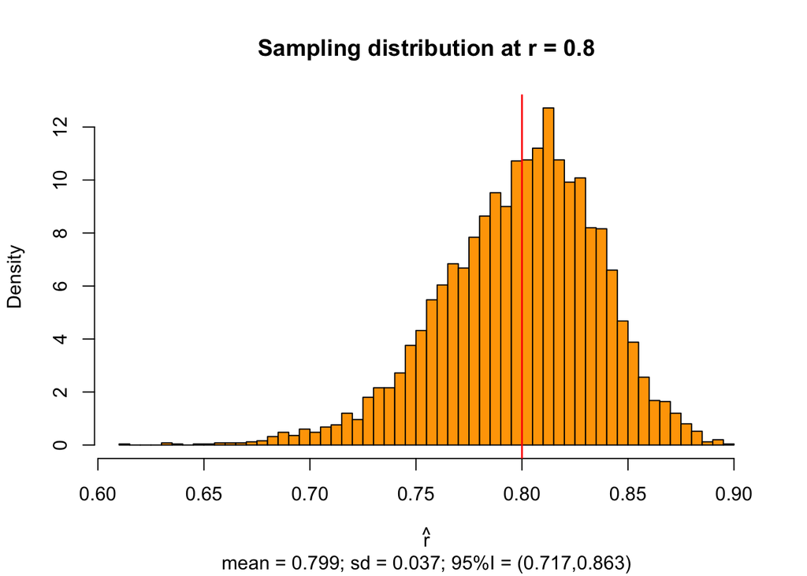

```r
#function to generate a pair of correlated variables from lecture 6
gen.cor.pair <- function(r, n){ #r is target correlation, n is sample size
 u = rnorm(n, 0, sqrt(abs(r))) #temporary variable that is used for generating x1 and x2
 x1 = scale(u + rnorm(n, 0, sqrt(1 - abs(r))))
 x2 = scale(sign(r)*u + rnorm(n, 0, sqrt(1 - abs(r))))
 cbind(x1, x2) #return matrix
}

n = 100
r.true = 0.8
R = 5000 #replicates of data set
r.est = replicate(R, cor(gen.cor.pair(r = r.true, n = n))[1,2]) #returns cor(x,y) for R indep. data sets
hist(r.est, breaks = 50, main = paste0("Sampling distribution at r = ",r.true), col = "orange",
     xlab = expression(hat(r)), prob = T, sub = paste0(
       "mean = ",round(mean(r.est),3),"; sd = ",round(sd(r.est),3),"; 95%I = (",
       round(quantile(r.est,c(0.025)),3),",",
       round(quantile(r.est,c(0.975)),3),")"))
abline(v = r.true, col = "red", lwd = 1.5)
```

We see that with $n=100$ the estimates vary from 0.60 to 0.90, with mean close to the true value (in red) but some skew to left.

In real life we do not have a luxury of 5000 independent data sets from which to compute a mean and an interval, but instead we have only one data set of $n$ observations. Let’s generate such a single data set.

```r
X = gen.cor.pair(r = r.true, n = n)
r.est = cor(X)[1,2]
r.est
```

```
## [1] 0.7637661
```

This particular data set gives a point estimate of $\widehat{r}=0.764$. By observing this value alone we have no idea how much the estimate could vary if we had had additional samples from the population.

If we happen to be aware of inference about correlation coefficient, we can estimate the 95% CI using [Fisher’s transformation](https://en.wikipedia.org/wiki/Fisher_transformation) as

```r
tanh(atanh(r.est)+c(-1,1)*1.96*1/sqrt(n-3)) #95%CI for cor from Fisher's transf.
```

```
## [1] 0.6674799 0.8349312
```

However, Fisher’s transformation is a specific trick applicable only to correlation coefficient estimation and next we will use a more general approach of bootstrap estimation to derive the confidence interval. This happens as follows

1. Resample $B$ data sets of size $n$, each **with replacement** from among the original data set $X$. These $B$ resampled data sets are called **bootstrap samples**, and denoted by $X^*_1,\ldots,X_B^*$ to distinguish them from the original data set $X$.
2. Use the distribution of the statistic of interest over the bootstrap samples as a (posterior) distribution for the statistic of interest.

Let’s first see how this works in our case, and then discuss more about the motivation and assumptions behind the procedure.

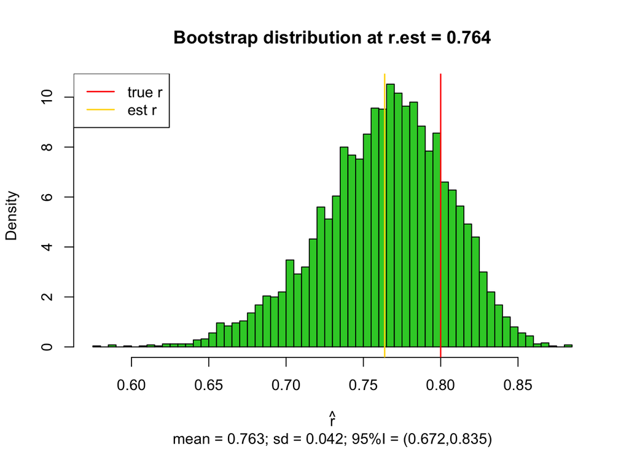

```r
B = 5000 #bootstrap samples
r.boot = replicate(B, cor(X[sample(1:n, n, replace = T),])[1,2])
hist(r.boot, breaks = 50, main = paste0("Bootstrap distribution at r.est = ",round(r.est,3)),
     col = "limegreen", xlab = expression(hat(r)), prob = T,
     sub = paste0(
       "mean = ",round(mean(r.boot),3),
       "; sd = ",round(sd(r.boot),3),
       "; 95%I = (", round(quantile(r.boot,c(0.025)),3),",",round(quantile(r.boot,c(0.975)),3),")"))
abline(v = r.true, col = "red", lwd = 1.5)
abline(v = r.est, col = "gold", lwd = 1.5)
legend("topleft", lwd = 1.5, col = c("red","gold"), leg = c("true r","est r"), lty = c(1,1))
```

By interpreting this distribution as a posterior distribution of $r$ we can say that a 95% *credible interval* is (0.672,0.835). Often exactly the same interval is interpreted as a *confidence interval* so both Bayesian and frequentist interpretations are used for this bootstrap interval.

**(Philosophical) Discussion:** Even though both Bayesian and frequentist interpretations are used for this interval, there seems not to be good arguments why this interval is a suitable confidence interval, other than acknowledging that it is actually a credible interval that has a good frequentist calibration. For example, a nice treatment of the bootstrap by [Hesterberg (2014)](https://arxiv.org/abs/1411.5279) p.54 says that “*The bootstrap percentile interval has no particular derivation - it just works. This is uncomfortable for a mathematically-trained statistician, and unsatisfying for a mathematical statistics course.*” This “problem” may exist with the frequentist interpretation, but does not exist with the Bayesian interpretation, because there this percentile interval of the bootstrap sample is the most obvious estimate for the credible interval.

We see that in our example case this interval agrees well with the Fisher’s transformation above (0.667,0.835), but let’s also do some empirical testing to see how this interval is calibrated over possible other data sets that we could have used for making the bootstrap sample. Let’s make 2000 replicates of the whole bootstrap procedure, each replicate coming from its own data set, and compute the proportion of the replicates where the 95% bootstrap interval contains the true value of $r$.

```r
B = 1000
R = 2000
ci.boot = matrix(NA, ncol = 2, nrow = R)
for(ii in 1:R){
  X = gen.cor.pair(r = r.true, n = n) #generate one pair of predictors
  r.boot = replicate(B, cor(X[sample(1:n, n, replace = T),])[1,2])
  ci.boot[ii,] = quantile(r.boot,c(0.025,0.975))
}
#Count in which proportion of data sets the bootstrap 95%CI contained the true r
mean(ci.boot[,1] <= r.true & r.true <= ci.boot[,2])
```

```
## [1] 0.9335
```

We have pretty well-calibrated 95% intervals (in frequentist sense) from the bootstrap samples, meaning that ~95% of the intervals indeed contain the true parameter. (To be precise, here the intervals are a bit narrow with coverage of about 93.4% but it still gives a good idea where 95% of the mass is.)

*To conclude*: Based on the single data set we estimated $\widehat{r}=0.764$, (we don’t use the bootstrap sample for this point estimate but only the `cor()` applied to our original data set), with a 95% credible (or confidence) interval of (0.67,0.84).

#### What exactly is the bootstrap used for ?

The term “bootstrap” (likely) originates from the saying [“to pull oneself up by one’s bootstraps”](https://en.wiktionary.org/wiki/pull_oneself_up_by_one%27s_bootstraps), which means to complete an impossible task. Bradley Efron introduced the term in his 1979 [paper](https://projecteuclid.org/euclid.aos/1176344552) about the method. The “impossible-sounding” task here is to estimate the sampling distribution of the estimator by using only one available estimate. The reason that the task is not quite as impossible as it may sound is that the single available estimate results from a data set of $n$ data points, and the variation of the estimator can be approximated by resampling additional data sets of the same size as the original data set ($n$), using the available data set as an approximation to the target population.

We use bootsrap to estimate the uncertainty in our statistic of interest. Typical cases are to use SD of the bootstrap sample to estimate SE of the parameter estimate and to use the $\alpha\cdot 100$% interval of bootstrap sample to approximate the corresponding credible/confidence interval for the parameter. Bootstrap works better, the more symmetric and unbiased the sampling distribution is, and bootstrap can fail if the shape of the distribution very strongly depends on the parameter value, or if the sample size is very small.

Note that we **do not** use bootstrap to try to somehow make our single point estimate more accurate. Such a task indeed remains impossible! By resampling from the existing data set we cannot create more accuracy about the parameter value compared to what we already have extracted from the available data set. Bootstrap simply helps us to approximate how much our point estimate might vary if we had observed another data set of similar size from the same population (frequentist interpretation), or to approximate the posterior distribution of the parameter of interest (Bayesian interpretation).

#### Bootstrap resamples **with replacement**

When the original data is $X=(x_1,\ldots,x_n)$, a bootstrap sample $X^*=(x_1^*,\ldots,x_n^*)$ is a sample of size $n$ from the original data, where each $x_j^*$ has been sampled independently from among the $n$ values of $X$, with equal probability $\frac{1}{n}$ given for each data point $x_k$ of $X$. In other words, for any bootstrap sample $X^*$, $\textrm{Pr}(x_j^* = x_k) = \frac{1}{n}$ for all pairs $j,k\in\{1,\ldots, n\}$.

In particular, it follows that the bootstrap sample can include a single data point $x_k$ many times and can miss some other value $x_{k'}$ completely. Actually, the probability that a bootstrap sample misses a particular data point $x_k$ is $(1-\frac{1}{n})^n \underset{n\to\infty}{\longrightarrow}e^{-1}\approx 0.368.$ Thus, in large samples, only about 63.2% of the data points are included in any one bootstrap sample.

For example, if we have observed data set $X=(0.6,1.3,2.0)$ we could make $3^3=27$ bootstrap samples, including, e.g., $(0.6,0.6,0.6)$,$(1.3,2.0,1.3)$ and $(2.0, 0.6, 1.3)$.

#### Why does bootstrap work?

The non-parameteric bootstrap, that we have been considering, can be seen as first building an estimate for the probability distribution $f(x)$ of the data $x$ in the target population, and second using that estimate of the distribution for inference about the statistic of interest, $\theta = \theta(x)$, in the target distribution.

Thus bootstrap does inference based on the assumption that the empirical distribution $\widehat{f}$ of the data points observed in the data set $X$ is a good approximation to the complete target distribution of the data points that could have been sampled / will be sampled in the future. This empirical distribution simply puts a point mass of $\frac{1}{n}$ on each observed data point and assumes that no other data points are possible. It is clear that this is a crude approximation, and depends on the situation and sample size how good results it gives.

A Bayesian interpretation of bootstrap, first framed by Rubin in [1981](https://projecteuclid.org/euclid.aos/1176345338), assumes that we are estimating the discrete probability of observing each possible data point. We put an uninformative prior distribution on the probabilities of all possible data points and then we update the probabilities as we observe new data points. Under this very naive model, the expected value of the posterior distribution after observing $n$ data points is the bootstrap distribution where each observed point has probability of $\frac{1}{n}$, and there is 0 probability for any so far unobserved data point. It follows that the posterior distribution for any given statistic $\theta = \theta(x)$ can then be approximated by the bootstrap method as described above. A detailed explanation is given by [Rasmus Bååth](http://www.sumsar.net/blog/2015/04/the-non-parametric-bootstrap-as-a-bayesian-model/).

#### Read from ISL “5.2 The Bootstrap”

## Bootstrap with penalized regression

The results from LASSO are:

```r
library(MASS)
library(glmnet)
y = scale(Boston$medv)
X = scale(as.matrix(Boston[,-which(names(Boston)=="medv")]))

#Let's apply the standard LASSO estimation at lambda.1se
cv.lasso = cv.glmnet(x = X, y = y, alpha = 1)
lasso.coef = as.numeric(coef(cv.lasso$glmnet.fit, s = cv.lasso$lambda.1se))
cv.lasso$lambda.1se
```

```
## [1] 0.02839794
```

```r
data.frame(lasso.coef, row.names = c("intcept",colnames(X)))
```

```
##            lasso.coef
## intcept -4.192642e-16
## crim    -3.028936e-02
## zn       2.129334e-02
## indus    0.000000e+00
## chas     6.199843e-02
## nox     -9.238078e-02
## rm       3.247971e-01
## age      0.000000e+00
## dis     -1.445185e-01
## rad      0.000000e+00
## tax      0.000000e+00
## ptratio -1.919869e-01
## black    7.024556e-02
## lstat   -4.036471e-01
```

Let’s see whether the same coefficients are 0 also in all/most/some bootstrap samples. We will simply bootsrap the rows of the `Boston` data set, fit LASSO model and collect the `lambda` parameter and all the coefficients. We will do this also for `lambda.min` simultaneously.

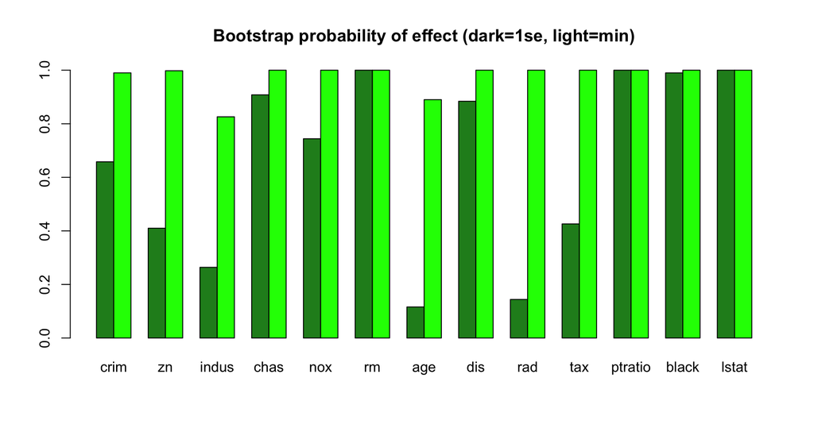

```r
n = length(y)
B = 500 #bootstrap samples
boot.coef.1se = matrix(NA, nrow = B, ncol = ncol(X)+1) #+1 for the intercept
colnames(boot.coef.1se) = c("intcept",colnames(X))
boot.coef.min = boot.coef.1se
boot.lambda = matrix(NA, nrow = B, ncol = 2)
colnames(boot.lambda) = c("1se","min")
for(ii in 1:B){
  boot.ind = sample(1:n, size = n, replace = T) #bootstrap indexes
  XX = X[boot.ind,]
  yy = y[boot.ind]
  boot.cv.lasso = cv.glmnet(x = XX, y = yy, alpha = 1)
  boot.coef.1se[ii,] = as.numeric(coef(boot.cv.lasso$glmnet.fit, s = boot.cv.lasso$lambda.1se))
  boot.coef.min[ii,] = as.numeric(coef(boot.cv.lasso$glmnet.fit, s = boot.cv.lasso$lambda.min))
  boot.lambda[ii,] = c(boot.cv.lasso$lambda.1se, boot.cv.lasso$lambda.min)
}
prob.nonzero.1se = apply(abs(boot.coef.1se) > 1e-10, 2, mean) #proportion where each coef was > 1e-10
prob.nonzero.min = apply(abs(boot.coef.min) > 1e-10, 2, mean)

barplot(rbind(prob.nonzero.1se[-1],prob.nonzero.min[-1]), beside = T,
        col = c("forestgreen", "green1"), main = "Bootstrap probability of effect (dark=1se, light=min)")
```

At `lambda.min` we see that there is little shrinkage, which reflects the fact that this data set does not seem to have many unnecessary predictors.

How much estimated `lambda` has varied across bootstrap?

```r
summary(boot.lambda)
```

```
##       1se               min
##  Min.   :0.01533   Min.   :0.0005163
##  1st Qu.:0.03072   1st Qu.:0.0007457
##  Median :0.03810   Median :0.0008656
##  Mean   :0.04153   Mean   :0.0013371
##  3rd Qu.:0.04723   3rd Qu.:0.0017203
##  Max.   :0.13161   Max.   :0.0058687
```

Not very much and again we see that `lambda.min` is often very close to zero meaning that cross-validation suggests that there is no need for shrinkage.

We can now also look at the variation in the values of coefficients.

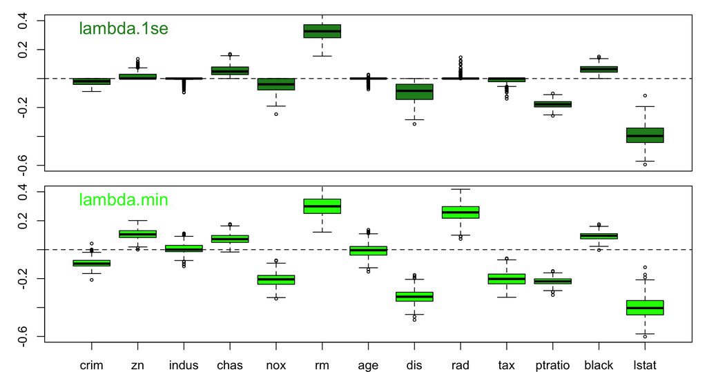

```r
par(mfrow = c(2,1))
par(mar=c(1,3,1,1))
boxplot(boot.coef.1se[,-1], col = "forestgreen", main = "", xaxt = "n", ylim = c(-0.6,0.4), cex = 0.5)
abline(h = 0, lty = 2)
text(1.7, 0.35, "lambda.1se", cex = 1.4, col = "forestgreen")
par(mar=c(2,3,0,1))
boxplot(boot.coef.min[,-1], col = "green1", main = "", ylim = c(-0.6,0.4), cex = 0.5)
abline( h = 0, lty = 2)
text(1.7, 0.35, "lambda.min", cex = 1.4, col = "green1")
```

In 1se plot, `lstat` is having the largest magnitude, followed by `rm` and then `ptratio`. The first two clearly separate from the rest and hence we can conclude that they will be the once that explain the most variance (since fot standardized variables the squared effect size is directly proportional to the variance explained).

The results are broadly similar in min plot, but there are some clear differences:

1. At `lambda.min` the shrinkage is very weak and does not set any parameters exactly to 0 like in the `lambda.1se` model. Even `indus` and `age`, whose medians are 0 also with `lambda.min`, do show some variation around 0 in the `lambda.min` model.
2. Some coefficients like `zn`, `nox`, `dis`, `rad` and `tax` show clearly larger magnitude average effects in `lambda.min` than in `lambda.1se`.

Let’s study the second observation in more detail by making scatter plots of the estimated coefficients of `zn` vs. `dis`, and `rad` vs `tax`.

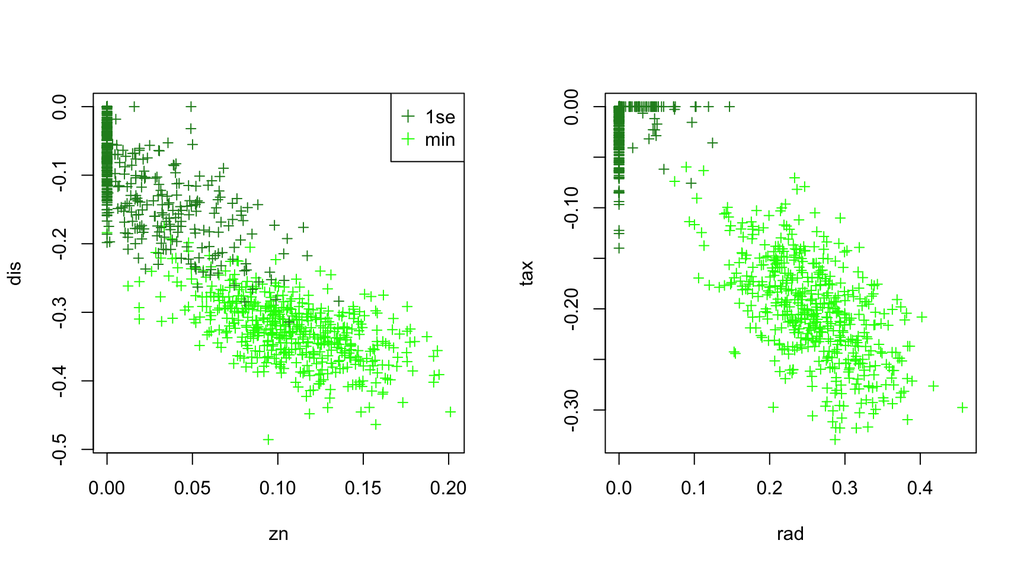

```r
par(mfrow=c(1,2))
cols = rep( c("green1","forestgreen"), each = B)
x1 = c(boot.coef.min[,"zn"], boot.coef.1se[,"zn"])
x2 = c(boot.coef.min[,"dis"], boot.coef.1se[,"dis"])
plot(x1, x2, xlab = "zn", ylab = "dis", cex = 0.8, pch = 3, col = cols)
legend("topright", leg = c("1se","min"), col = c("forestgreen", "green1"), pch = 3)
x1 = c(boot.coef.min[,"rad"], boot.coef.1se[,"rad"])
x2 = c(boot.coef.min[,"tax"], boot.coef.1se[,"tax"])
plot(x1, x2, xlab = "rad", ylab = "tax", cex = 0.8, pch = 3, col = cols)
```

We see a trend of negative correlation for both pairs likely meaning that, from the point of view of the model fit, one can compensate an increase in the magnitude of the first variable by an increase in the opposite direction of the second variable. When the model is more penalized (dark green), then both values shrink toward 0, but when there is less penalization, then the values can grow together in magnitude.

Finally, with bootstrap, we could now report a 95% credible interval from the LASSO model. For example for the `lstat` these would be

```r
res = rbind(quantile(boot.coef.1se[,"lstat"],c(0.025,0.975)),
            quantile(boot.coef.min[,"lstat"],c(0.025,0.975)))
rownames(res) = c("1se", "min")
res
```

```
##           2.5%      97.5%
## 1se -0.5221777 -0.2492009
## min -0.5452871 -0.2395490
```

These analyses were simple to do and results seem plausible based on what we have seen earlier with this Boston data set. However, bootstrap is (possibly) a crude approximation to the actual posterior distribution, and next we will look at more exact results for the posterior distribution of a LASSO model.

## Bayesian lasso with `blasso()`

In lecture notes 6 we established that the LASSO model, that was derived as the optimum of a penalized likelihood function, is simultaneously a maximum-a-posteriori (MAP) estimate of a Bayesian model. The central property of this Bayesian model was that the prior distribution on all coefficients was the Laplace distribution that had a sharp peak at 0, which then leads to a situation where the optimum value maximizing the posterior distribution (or, equivalently, minimizing the penalized likelihood) has typically several coefficient set exactly to 0.

Let’s now explore the posterior distributions of the coefficients under a **[Bayesian LASSO](https://people.eecs.berkeley.edu/~jordan/courses/260-spring09/other-readings/park-casella.pdf)** model, formulated by Park & Casella (2008). The difference to pure penalized likelihood version of LASSO is that here we introduce explicit prior distributions for all parameters in the model and use computational techniques called Markov chain Monte Carlo (MCMC) to estimate the posteriors. Technically this is more complicated than the bootstrapping above, but luckily Robert Gramacy has implemented it in [`blasso()`](https://www.rdocumentation.org/packages/monomvn/versions/1.9-10/topics/blasso) function of `monomvn` package.

**Note:** An attempt to `install.packages("monomvn")` showed that `monomvn` seems not to be available in CRAN at the moment. You might need to directly use source file https://cran.r-project.org/src/contrib/Archive/monomvn/monomvn_1.9-10.tar.gz and  
try installing it with `install.packages("your_path/monomvn_1.9-10.tar.gz", repos = NULL, type = "source")`. I had some troubles getting it compiled, so we are not relying on this package in the exercises.

The Bayesian model behind blasso includes also the parameters $\mu$, $\lambda$ and $\sigma^2$ and hence they also need explicit prior distributions. The Bayesian LASSO is defined hierarchically so that first $\mu$, $\lambda$ and $\sigma^2$ are given “uninformative” prior distributions to implement the idea that for these values the information would hopefully come almost solely from the data, not from the prior. Conditional on $\lambda$ and $\sigma^2$, we then define the LASSO prior (Laplace distribution) for the coefficients. This prior allows a strong shrinkage to the coefficient compared to what the data alone favors, and hence this part of the model has a very “informative” prior. To complete the model, we state that the observed data is a result of Gaussian errors added to the linear predictor, just like in the standard linear model. In formulas the model specification is
$$\begin{eqnarray*}
\mu &\sim& 1 \textrm{ (i.e., a flat prior over the real numbers)}\\
\sigma^2 &\sim& 1/\sigma^2 \textrm{ (i.e., a flat prior for $\log(\sigma^2)$)}\\
\lambda^2 &\sim& \textrm{"uninformative" Gamma distribution}\\
(\beta_j \,|\,\sigma,\lambda) &\sim& \textrm{Laplace}(0, \sigma/\lambda), \textrm{ for all } j=1,\ldots,p. \\
(y_i \, | \, \mu, \pmb{\beta}, \sigma^2, \pmb{X}_i) &\sim& \mathcal{N}(\mu + \pmb{X}_i^T \pmb{\beta}, \sigma^2) \textrm{ for all } i=1,\ldots,n.
\end{eqnarray*}$$

With these distributions, the Bayes rule tells that the joint posterior distribution of all unknown parameters is proportional to prior x likelihood:
$$\textrm{Pr}(\pmb{\beta},\mu,\sigma^2,\lambda^2\,|\,\pmb{y},\pmb{X}) \propto
\textrm{Pr}(\pmb{y}\,|\,\pmb{\beta},\mu,\sigma^2,\lambda^2,\pmb{X})
\cdot \textrm{Pr}(\pmb{\beta}\,|\,\sigma^2,\lambda^2)\textrm{Pr}(\mu)\textrm{Pr}(\sigma^2)\textrm{Pr}(\lambda^2),$$
where the first term on the right hand side is the Gaussian likelihood of the linear model, and the remaining 4 terms are the prior distributions that are defined hierarchically (first independent flat priors on $\mu$, $\sigma^2$ and $\lambda^2$, and then the Laplace prior on $\pmb{\beta}$ conditional on values of $\sigma^2$ and $\lambda^2$). `blasso()` uses an MCMC algorithm to numerically sample from this distribution.

Let’s run `blasso()`. It requires number of MCMC iterations `T` as input. More iterations will lead to more accurate results, but will also take more time. `RJ=F` means the Bayesian LASSO and `RJ=T` adds a Bayesian variable selection via Reversible Jump MCMC. For now we use `RJ=F`. MCMC produces one set of parameter values per each iteration and these values can be interpreted as samples from the posterior distribution, except at first few iterations, where the algorithm is still dependent on its initial values. Therefore, initial iterations are discarded as a “burn-in” period of the algorithm. Here we discard the first 20 iterations as burn-in. Let’s run `blasso` and compare the posteriors to the earlier bootstrap results (`lambda.min`) via boxplots.

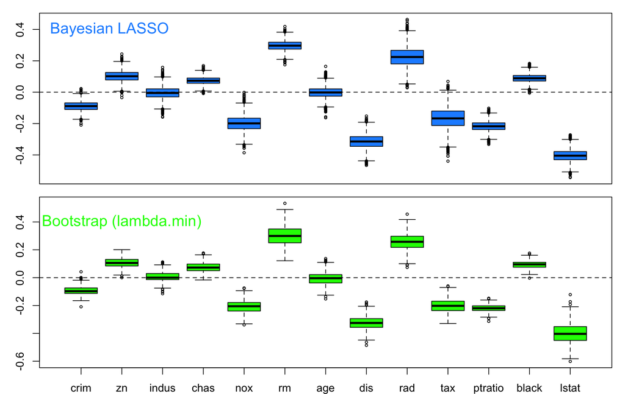

```r
library("monomvn")
mcmc.niter = 5000 #how many iterations to run?
blasso.fit = blasso(X = X, y = y, T = mcmc.niter, RJ = F, case = "default", verb = 0)
burnin = 20 #this many first iterations will be discarded as an initial "burn-in" period
iters = burnin:mcmc.niter #use these iterations in results
par(mfrow = c(2,1))
par(mar=c(1,3,1,1))
boxplot(blasso.fit$beta[iters,], col = "dodgerblue", cex = 0.5,
        names = colnames(boot.coef.min)[-1], main = "", xaxt = "n")
abline(h = 0, lty = 2)
text(1.7, 0.4, "Bayesian LASSO", cex = 1.4, col = "dodgerblue")
par(mar=c(2,3,0,1))
boxplot(boot.coef.min[,-1], col = "green1", main = "", cex = 0.5)
abline( h = 0, lty = 2)
text(2,0.4,"Bootstrap (lambda.min)", cex = 1.4, col = "green1")
```

The results are highly similar and we can conclude that the bootstrap produced a very good picture of the posterior distribution of the LASSO model.

The Boston data set didn’t provide much need for stronger shrinkage so let’s next see how Bayesian LASSO works with a more sparse test case.

**Example 7.1** Let’s generate similar data as in Notes 6 with only a couple of important variables and many null variables. To keep plots neat, let’s use only $p=30$ variables of which first 3 have real effects, each explaining about 5% of variance of the outcome, and let’s consider $n=250$ individuals.

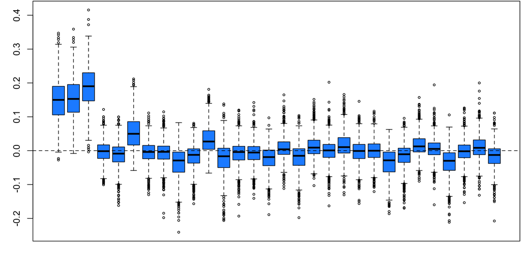

```r
set.seed(122)
p = 30
n = 250
phi = 0.05 #variance explained by x_1, should be 0 < phi < 1.
b = rep(c(sqrt(phi / (1-phi)), 0), c(3, p-3)) #effects 1,2,3 are non-zero, see Lect. 0.1 for "phi"
X = matrix(rnorm(n*p), nrow = n) #columns 1,2,3 of X will have effects, other 27 cols are noise
eps = scale(rnorm(n, 0, 1)) #epsilon, error term
y = scale(X%*%b + eps) #makes y have mean = 1, var = 1

mcmc.niter = 1000 #how many iterations to run?
blasso.fit = blasso(X = X, y = y, T = mcmc.niter, RJ = F, case = "default", verb = 0)
burnin = 20 #this many first iterations will be discarded as an initial "burn-in" period
iters = burnin:mcmc.niter #use these iterations in results
par(mar = c(3,3,0.1,0.1))
boxplot(blasso.fit$beta[iters,], col = "dodgerblue", main = "", xaxt = "n", cex = 0.5)
abline(h = 0, lty = 2)
```

We see that the first three predictors are having larger effects than most others, but the model does not strongly force the others to stay at 0. This is because the model has a single shrinkage parameter $\lambda$ that needs to balance the opposite needs between the first 3 variables and the rest. An extension of `blasso()` includes variable selection (`RJ = T`). That extension includes a prior distribution on the number of non-zero coefficients, that by default is the uniform distribution on $\{1,\ldots,p\}$, and hence then the model is explicitly allowing some coefficients be exactly zero while others may have larger values that may or may not need shrinkage via $\lambda$ parameter. Let’s try this out.

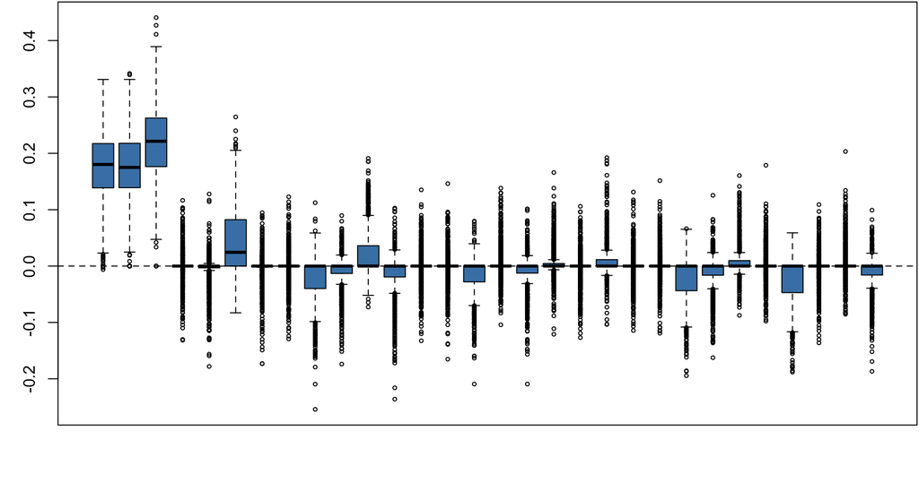

```r
blasso.rj.fit = blasso(X = X, y = y, T = mcmc.niter, RJ = T, case = "default", verb = 0)
par(mar = c(3,3,0.1,0.1))
boxplot(blasso.rj.fit$beta[iters,], col = "steelblue", main = "", xaxt = "n", cex = 0.5)
abline(h = 0, lty = 2)
```

Let’s plot the posterior median of the absolute values of each variable from with and without RJ-variable selection. Let’s add the diagonal and a red line to denote the true effect size in the simulation. Let’s use red for the 3 true effects and gray for the rest.

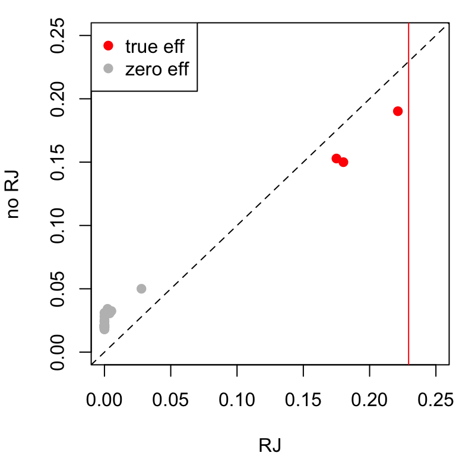

```r
x1 = apply(abs(blasso.rj.fit$beta[iters,]), 2, median)
x2 = apply(abs(blasso.fit$beta[iters,]), 2, median)
par(mar = c(4,4,1,0.3))
plot(x1, x2, xlab = "RJ", ylab = "no RJ", col = rep(c("red","gray"),c(3,p-3)),
     pch = 19, xlim =c(0,0.25), ylim = c(0,0.25))
legend("topleft", col= c("red","gray"), pch = 19, leg = c("true eff","zero eff"))
abline(0,1, lty = 2)
abline(v = b[1], lty = 1, col = "red") #true value in simulation
```

We see that with variable selection we estimate better the effects of both the true effects and the absolute values of the zero effects. This is because as the variable selection sets some noise variables to 0, we do not need to make global $\lambda$ that large to get a good model, and hence we need not penalize the true effects as much as we do without the variable selection.

### Other methods

Here we took a look at two standard and complementary ways to assess uncertainty in penalized regression models.

More generally, statistical inference for high dimensional models is very active topic of research. See, for example, work on [Selective inference](https://github.com/selective-inference/R-software).